# Beta regression and panel data

Gadir Mamedov

## 0.2 Helpers

Libraries

```r
library(forecast)
library(reshape)
library(betareg)
library(plm)
library(ggplot2)
library(knitr)
library(dplyr)
library(summarytools)
library(Hmisc)
library(car)
library(sjPlot)
library(lmtest)
```

Function to show output in the notebook

```r
show_output = function(model, robust = FALSE){
  model = model
  robust = robust
  if(robust == TRUE){
    knitr::knit_print(sjPlot::tab_model(model, show.se = TRUE, show.fstat = TRUE, show.aic = TRUE, show.loglik = TRUE, p.style = "stars", emph.p = TRUE, digits = 2, robust = TRUE, collapse.ci = TRUE))
  }else{
    knitr::knit_print(sjPlot::tab_model(model, show.se = TRUE, show.fstat = TRUE, show.aic = TRUE, show.loglik = TRUE, p.style = "stars", emph.p = TRUE, digits = 2, collapse.ci = TRUE))
  }
}
```

## 0.3 Data

> Data can be downloaded from this link and saved as a csv file.

[LINK to dataset](https://raw.githubusercontent.com/gzmamedov/Thesis2021/main/mamedov_thesis_data.csv)

```r
df_base = read.csv("mamedov_thesis_data.csv")
```

## 0.4 Summary of all variables

This dataset is a bit messy, and there is a lot of not relevant variables.

```r
print(dfSummary(df_base, valid.col = FALSE, graph.magnif = 0.75),
      max.tbl.height = 300, method = "render")
```

## 0.5 Dependent variables

1st variable - state reforms only 2nd variable - IPI-based progress retrieved from the reports 3nd variable - Control of Corruption index rescaled from 0 to 1 for the beta regression model.

```r
ggplot(df_base) +
  geom_line(aes(year,progress_corr_only, col = "yellow")) +
  geom_line(aes(year, progress_ipi, col = "red"))+
  geom_line(aes(year, coc_norm,col = "blue"))+
  facet_wrap(~country) +
  scale_x_continuous(breaks = seq(2003,2020, 1))+
  theme(axis.text.x = element_text(angle = 45, vjust = 0.5, hjust=1))+
  scale_color_identity(name = "Progress index",
                          breaks = c("yellow", "red", "blue"),
                          labels = c("Progress in state reforms", "IPI-based progress", "Control of Corruption Index"),
                          guide = "legend")+
  ylab("Progress")+
  xlab("Year")+
  ggtitle("Progress in the fight against corruption")
```

### 0.5.1 Control of corruption index - original scale

```r
ggplot(df_base) +
  geom_line(aes(year, e_wbgi_cce))+
  facet_wrap(~country) +
  scale_x_continuous(breaks = seq(2003,2020, 1))+
  theme(axis.text.x = element_text(angle = 45, vjust = 0.5, hjust=1))+
  ylab("CoC original scale")+
  xlab("Year")
```

Control of Corruption index is less volatile for majority of countries, and only Georgia has seen the growth over years. Thus we can conclude that not counting for time effect can lead to unnecessary multiplication of data. IPI-based progress index shows less association between years within countries.

## 0.6 Notes before running models

We will use two types of regression models:

- Beta regression model (from betareg library)
- Panel regression (from plm library)

Whar R-squared is used for each model?

- **Beta-regression**

> Pseudo-R2 formula = cor(log(y/(1 - y)), x %*% beta)^2
- **Panel regression**

[Source](https://stats.stackexchange.com/questions/79723/interpretation-of-r2-in-fixed-effects-panel-regression/79734#79734)

**overall 𝑅2**: that’s the usual 𝑅2 which you would get from regressing your dependent variable 𝑌𝑖,𝑡 on the explanatory variables 𝑋𝑖,𝑡.

**between 𝑅2**: if you collapse your data and remove the time component by taking the means of your variables for each panel unit individually, the 𝑅2 from regressing these time de-meaned data gives the between 𝑅2. That’s the regression 𝑌𝑖,. on 𝑋𝑖,. (where . replaces the time-subscript to show that time has been averaged out for each panel unit 𝑖). So this disregards all the within information in the data.

**within 𝑅2**: this comes from the prediction equation (𝑌ˆ𝑖,𝑡−𝑌⎯⎯⎯⎯ˆ𝑖,.)=(𝑋𝑖,𝑡−𝑋⎯⎯⎯⎯⎯𝑖,.)𝛽ˆ), where 𝑌⎯⎯⎯⎯ˆ𝑖,. and 𝑋⎯⎯⎯⎯⎯ˆ𝑖,. are the grand means of your variables. So the within 𝑅2 gives you the goodness of fit measure for the individual mean de-trended data which disregards all the between information in the data.

For each type of PLM regression we get a corresponding R2. Beta regression, instead, shows only overall R2. It is misleading to compare within-R2 (which explains variance - variance explained by fixed effects) and overall R2 of the beta regression predictions. Thus, one solution is to compare overall R-squared. Basically, our idea is to get the best working model or understand if we get similar results using different models.

## 0.7 Only fixed effects models - Beta regression

### 0.7.1 IPI-based index

```r
model_ipi_only_fixed  = betareg(progress_ipi~country |country, link = "logit", data = df_base)
```

progress_ipi

Predictors

Estimates

std. Error

(Intercept)

0.79 *  
(0.63 – 0.99)

0.09

country [Armenia]

1.05  
(0.72 – 1.54)

0.21

country [Azerbaijan]

0.88  
(0.63 – 1.22)

0.15

country [Bosnia and  
Herzegovina]

0.59 ***  
(0.44 – 0.78)

0.09

country [Croatia]

2.20 **  
(1.25 – 3.85)

0.63

country [Georgia]

2.01 ***  
(1.34 – 3.03)

0.42

country [Kosovo]

0.81  
(0.57 – 1.15)

0.15

country [Moldova]

1.55 *  
(1.02 – 2.34)

0.33

country [Montenegro]

1.29  
(0.93 – 1.78)

0.21

country [North Macedonia]

1.42 *  
(1.03 – 1.97)

0.24

country [Serbia]

1.27  
(0.94 – 1.72)

0.20

country [Ukraine]

1.33  
(0.89 – 1.98)

0.27

Observations

148

R<sup>2</sup>

0.324

AIC

-172.620

log-Likelihood

110.310

- p<0.05 ** p<0.01 *** p<0.001

**DIAGNOSTICS**

Breush-Pagan test

```r
bptest(model_ipi_only_fixed)
```

```
    studentized Breusch-Pagan test

data:  model_ipi_only_fixed
BP = 19.819, df = 11, p-value = 0.04788
```

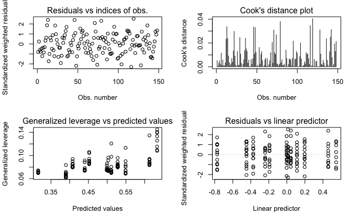

```r
par(mfrow = c(2, 2))
plot(model_ipi_only_fixed)
```

Durbin-Watson test

```r
dwtest(model_ipi_only_fixed)
```

```
    Durbin-Watson test

data:  model_ipi_only_fixed
DW = 1.2383, p-value = 9.081e-09
alternative hypothesis: true autocorrelation is greater than 0
```

Autocorrelation plot

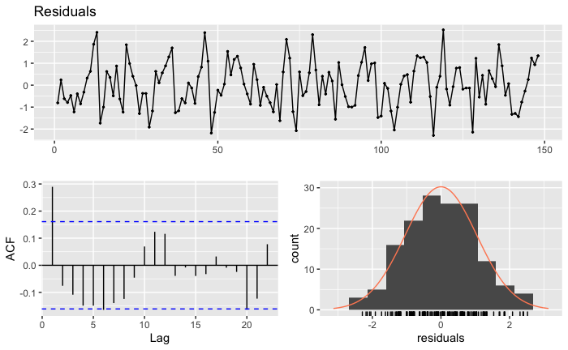

```r
checkresiduals(resid(model_ipi_only_fixed))
```

### 0.7.2 Control of Corruption index

coc_norm

Predictors

Estimates

std. Error

(Intercept)

0.45 ***  
(0.39 – 0.52)

0.03

country [Armenia]

1.04  
(0.85 – 1.28)

0.11

country [Azerbaijan]

0.21 ***  
(0.09 – 0.49)

0.09

country [Bosnia and  
Herzegovina]

1.59 ***  
(1.31 – 1.93)

0.16

country [Croatia]

3.94 ***  
(3.31 – 4.70)

0.35

country [Georgia]

6.33 ***  
(3.19 – 12.57)

2.21

country [Kosovo]

1.11  
(0.93 – 1.31)

0.10

country [Moldova]

0.73 **  
(0.58 – 0.93)

0.09

country [Montenegro]

2.58 ***  
(2.12 – 3.14)

0.26

country [North Macedonia]

2.39 ***  
(1.93 – 2.97)

0.26

country [Serbia]

1.82 ***  
(1.54 – 2.14)

0.15

country [Ukraine]

0.45 ***  
(0.33 – 0.61)

0.07

Observations

148

R<sup>2</sup>

0.368

AIC

-395.565

log-Likelihood

221.782

- p<0.05 ** p<0.01 *** p<0.001

**DIAGNOSTICS**

Breush-Pagan test

```r
bptest(model_coc_only_fixed)
```

```
    studentized Breusch-Pagan test

data:  model_coc_only_fixed
BP = 73.157, df = 11, p-value = 3.055e-11
```

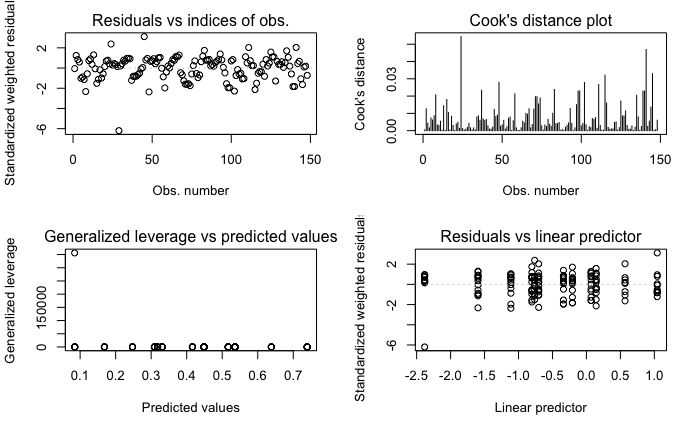

```r
par(mfrow = c(2, 2))
plot(model_coc_only_fixed)
```

Durbin-Watson test

```r
dwtest(model_coc_only_fixed)
```

```
    Durbin-Watson test

data:  model_coc_only_fixed
DW = 0.88465, p-value = 2.732e-15
alternative hypothesis: true autocorrelation is greater than 0
```

Autocorrelation plot

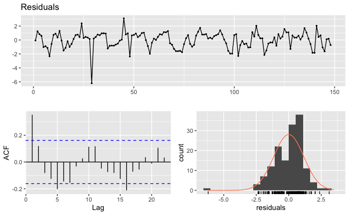

```r
checkresiduals(resid(model_coc_only_fixed))
```

## 0.8 Only predictors - Beta regression

### 0.8.1 IPI-based index

```r
model_ipi_only_pred = betareg(progress_ipi~membership+assistance_man_per_capita*e_wbgi_gee+export_per_capita+visa_dialogue+v2smpolsoc+socialisation_ipi+v2x_cspart-e_wbgi_gee |membership+assistance_man_per_capita*e_wbgi_gee+export_per_capita+visa_dialogue+v2smpolsoc+socialisation_ipi+v2x_cspart-e_wbgi_gee, link = "logit", data = df_base)
```

```r
show_output(model_ipi_only_pred)
```

progress_ipi

Predictors

Estimates

std. Error

(Intercept)

0.35 **  
(0.17 – 0.73)

0.13

membership [1]

0.58 ***  
(0.46 – 0.75)

0.07

assistance_man_per_capita

1.01 **  
(1.00 – 1.01)

0.00

export_per_capita

1.00 **  
(1.00 – 1.00)

0.00

visa_dialogue [1]

1.52 ***  
(1.22 – 1.90)

0.17

visa_dialogue [2]

1.35 *  
(1.02 – 1.79)

0.19

v2smpolsoc

1.15 **  
(1.05 – 1.25)

0.05

socialisation_ipi

1.09  
(0.36 – 3.33)

0.62

v2x_cspart

3.85 ***  
(2.02 – 7.32)

1.26

assistance_man_per_capita  
* e_wbgi_gee

1.02 ***  
(1.01 – 1.03)

0.00

Observations

148

R<sup>2</sup>

0.471

AIC

-209.816

log-Likelihood

124.908

- p<0.05 ** p<0.01 *** p<0.001

**DIAGNOSTICS**

Breush-Pagan test

```r
bptest(model_ipi_only_pred)
```

```
    studentized Breusch-Pagan test

data:  model_ipi_only_pred
BP = 12.07, df = 9, p-value = 0.2094
```

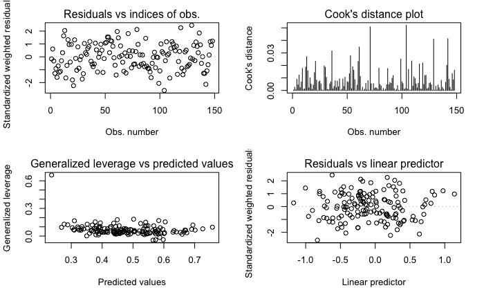

```r
par(mfrow = c(2, 2))
plot(model_ipi_only_pred)
```

Durbin-Watson test

```r
dwtest(model_ipi_only_pred)
```

```
    Durbin-Watson test

data:  model_ipi_only_pred
DW = 1.3954, p-value = 1.007e-05
alternative hypothesis: true autocorrelation is greater than 0
```

Autocorrelation plot

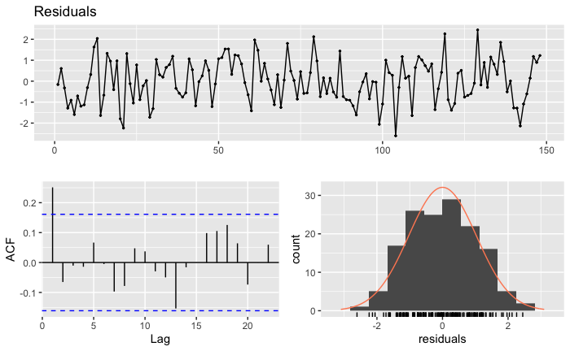

```r
checkresiduals(resid(model_ipi_only_pred))
```

### 0.8.2 Control of Corruption index

```r
show_output(model_coc_only_pred)
```

coc_norm

Predictors

Estimates

std. Error

(Intercept)

1.14  
(0.50 – 2.58)

0.48

membership [1]

2.56 ***  
(1.77 – 3.70)

0.48

assistance_man_per_capita

1.01 **  
(1.00 – 1.01)

0.00

export_per_capita

1.00  
(1.00 – 1.00)

0.00

visa_dialogue [1]

1.33 **  
(1.11 – 1.60)

0.12

visa_dialogue [2]

1.47 ***  
(1.21 – 1.77)

0.14

v2smpolsoc

0.89 **  
(0.82 – 0.96)

0.04

socialisation_coc

0.01 ***  
(0.00 – 0.04)

0.01

v2x_cspart

1.60  
(0.76 – 3.37)

0.61

Observations

148

R<sup>2</sup>

0.216

AIC

-236.217

log-Likelihood

136.109

- p<0.05 ** p<0.01 *** p<0.001

**DIAGNOSTICS**

Breush-Pagan test

```r
bptest(model_coc_only_pred)
```

```
    studentized Breusch-Pagan test

data:  model_coc_only_pred
BP = 42.403, df = 8, p-value = 1.138e-06
```

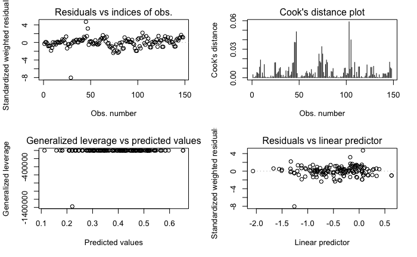

```r
par(mfrow = c(2, 2))
plot(model_coc_only_pred)
```

Durbin-Watson test

```r
dwtest(model_coc_only_pred)
```

```
    Durbin-Watson test

data:  model_coc_only_pred
DW = 0.80246, p-value = 2.056e-15
alternative hypothesis: true autocorrelation is greater than 0
```

Autocorrelation plot

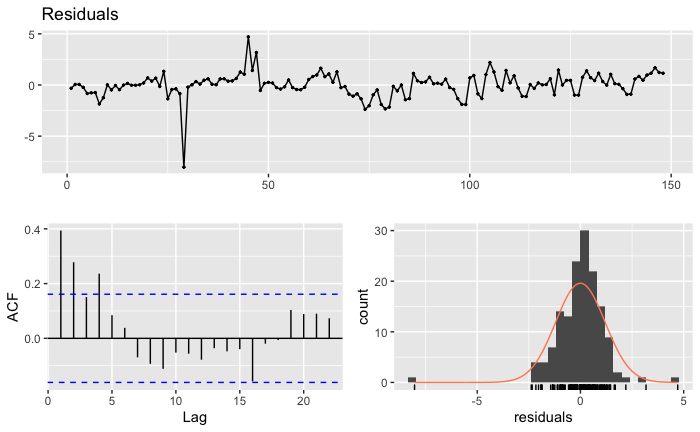

```r
checkresiduals(resid(model_coc_only_pred))
```

## 0.9 Fixed effects + predictors (no membership) - Beta regression

### 0.9.1 IPI-based index

```r
model_ipi_fe_pred = betareg(progress_ipi~country+assistance_man_per_capita*e_wbgi_gee+export_per_capita+visa_dialogue+v2smpolsoc+socialisation_ipig+v2x_cspart-e_wbgi_gee |country+assistance_man_per_capita*e_wbgi_gee+export_per_capita+visa_dialogue+v2smpolsoc+socialisation_ipi+v2x_cspart-e_wbgi_gee, link = "logit", data = df_base)
```

[output not shown]

progress_ipi

Predictors

Estimates

std. Error

(Intercept)

0.08 ***  
(0.04 – 0.18)

0.03

country [Armenia]

1.46  
(0.94 – 2.26)

0.33

country [Azerbaijan]

3.39 ***  
(1.98 – 5.82)

0.94

country [Bosnia and  
Herzegovina]

0.57 **  
(0.38 – 0.85)

0.12

country [Croatia]

1.03  
(0.56 – 1.89)

0.32

country [Georgia]

1.81 **  
(1.19 – 2.76)

0.39

country [Kosovo]

1.63 *  
(1.01 – 2.63)

0.40

country [Moldova]

2.42 ***  
(1.78 – 3.31)

0.38

country [Montenegro]

0.82  
(0.51 – 1.34)

0.20

country [North Macedonia]

1.19  
(0.78 – 1.82)

0.26

country [Serbia]

1.27  
(0.92 – 1.76)

0.21

country [Ukraine]

1.16  
(0.80 – 1.70)

0.23

assistance_man_per_capita

1.00  
(0.99 – 1.01)

0.00

export_per_capita

1.00  
(1.00 – 1.00)

0.00

visa_dialogue [1]

1.77 ***  
(1.44 – 2.18)

0.19

visa_dialogue [2]

1.70 ***  
(1.26 – 2.28)

0.26

v2smpolsoc

0.95  
(0.79 – 1.15)

0.09

socialisation_ipi

1.11  
(0.40 – 3.06)

0.58

v2x_cspart

12.87 ***  
(4.97 – 33.36)

6.26

assistance_man_per_capita  
* e_wbgi_gee

1.01  
(1.00 – 1.02)

0.01

Observations

148

R<sup>2</sup>

0.533

AIC

-208.428

log-Likelihood

144.214

- p<0.05 ** p<0.01 *** p<0.001

**DIAGNOSTICS**

Breush-Pagan test

```r
bptest(model_ipi_fe_pred)
```

```
    studentized Breusch-Pagan test

data:  model_ipi_fe_pred
BP = 19.397, df = 19, p-value = 0.4317
```

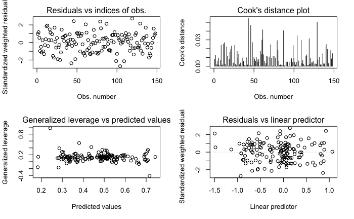

```r
par(mfrow = c(2, 2))
plot(model_ipi_fe_pred)
```

Durbin-Watson test

```r
dwtest(model_ipi_fe_pred)
```

```
    Durbin-Watson test

data:  model_ipi_fe_pred
DW = 1.5689, p-value = 3.09e-05
alternative hypothesis: true autocorrelation is greater than 0
```

Autocorrelation plot

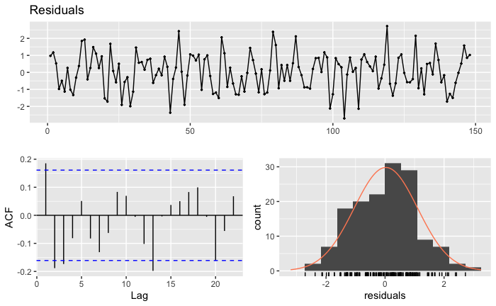

```r
checkresiduals(resid(model_ipi_fe_pred))
```

### 0.9.2 Control of Corruption index

```r
show_output(model_coc_fe_pred)
```

coc_norm

Predictors

Estimates

std. Error

(Intercept)

0.59 *  
(0.36 – 0.97)

0.15

country [Armenia]

0.97  
(0.78 – 1.21)

0.11

country [Azerbaijan]

0.30 **  
(0.13 – 0.71)

0.13

country [Bosnia and  
Herzegovina]

1.75 ***  
(1.44 – 2.11)

0.17

country [Croatia]

5.28 ***  
(4.52 – 6.16)

0.42

country [Georgia]

6.81 ***  
(3.37 – 13.74)

2.44

country [Kosovo]

1.02  
(0.81 – 1.29)

0.12

country [Moldova]

0.77 *  
(0.61 – 0.96)

0.09

country [Montenegro]

2.21 ***  
(1.83 – 2.68)

0.21

country [North Macedonia]

3.33 ***  
(2.74 – 4.04)

0.33

country [Serbia]

2.21 ***  
(1.90 – 2.59)

0.18

country [Ukraine]

0.49 ***  
(0.35 – 0.67)

0.08

assistance_man_per_capita

1.00  
(1.00 – 1.01)

0.00

export_per_capita

1.00 ***  
(1.00 – 1.00)

0.00

visa_dialogue [1]

1.28 ***  
(1.16 – 1.40)

0.06

visa_dialogue [2]

1.45 ***  
(1.32 – 1.59)

0.07

v2smpolsoc

0.98  
(0.91 – 1.05)

0.03

socialisation_coc

0.54  
(0.26 – 1.11)

0.20

v2x_cspart

0.76  
(0.43 – 1.33)

0.22

Observations

148

R<sup>2</sup>

0.387

AIC

-433.453

log-Likelihood

254.726

- p<0.05 ** p<0.01 *** p<0.001

**DIAGNOSTICS**

Breush-Pagan test

```r
bptest(model_coc_fe_pred)
```

```
    studentized Breusch-Pagan test

data:  model_coc_fe_pred
BP = 48.176, df = 18, p-value = 0.0001418
```

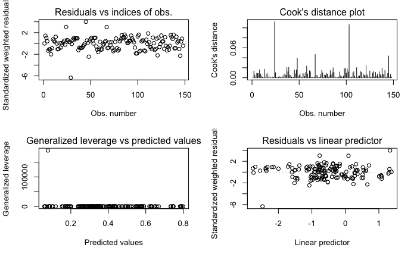

```r
par(mfrow = c(2, 2))
plot(model_coc_fe_pred)
```

Durbin-Watson test

```r
dwtest(model_coc_fe_pred)
```

```
    Durbin-Watson test

data:  model_coc_fe_pred
DW = 1.2178, p-value = 3.847e-10
alternative hypothesis: true autocorrelation is greater than 0
```

Autocorrelation plot

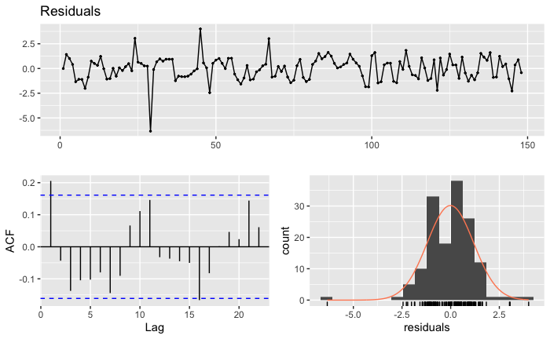

```r
checkresiduals(resid(model_coc_fe_pred))
```

## 0.10 Correction of beta regressions with lagged variables

Autocorrelation becomes an issue for all models. A very strong autocorrelation observed in the 1 step lag. Thus, if the lag is included into the model, we can capture this part and provide more robust results.

Let’s create lag variables. NAs filled with the same value.

```r
  lag_df = df_base %>%
  arrange(country, year) %>%
  group_by(country) %>%
  mutate(progress_ipi_lag = coalesce(Hmisc::Lag(progress_ipi), progress_ipi), coc_norm_lag = coalesce(  Hmisc::Lag(coc_norm), coc_norm), progress_ipi_logit_lag =  coalesce(Hmisc::Lag(progress_ipi_logit), progress_ipi_logit) , e_wbgi_cce_lag= coalesce(Hmisc::Lag(e_wbgi_cce), e_wbgi_cce) ) %>%
  ungroup()
```

```r
lag_df[c("country", "year", "progress_ipi", "progress_ipi_lag", "coc_norm", "coc_norm_lag", "progress_ipi_logit", "progress_ipi_logit_lag", "e_wbgi_cce", "e_wbgi_cce_lag")]
```

| country | year | progress_ipi | progress_ipi_lag | coc_norm | coc_norm_lag | progress_ipi_logit | progress_ipi_logit_lag | e_wbgi_cce | e_wbgi_cce_lag |
| --- | --- | --- | --- | --- | --- | --- | --- | --- | --- |
| Albania | 2005 | 0.3190145 | 0.3190145 | 0.225615764 | 0.225615764 | -0.7583045792 | -0.7583045792 | -0.786 | -0.786 |
| Albania | 2006 | 0.2454606 | 0.3190145 | 0.216748768 | 0.225615764 | -1.1229709813 | -0.7583045792 | -0.804 | -0.786 |
| Albania | 2007 | 0.5004601 | 0.2454606 | 0.273891626 | 0.216748768 | 0.0018402427 | -1.1229709813 | -0.688 | -0.804 |
| Albania | 2008 | 0.3888513 | 0.5004601 | 0.320197044 | 0.273891626 | -0.4521434385 | 0.0018402427 | -0.594 | -0.688 |
| Albania | 2009 | 0.4076273 | 0.3888513 | 0.347783251 | 0.320197044 | -0.3737826596 | -0.4521434385 | -0.538 | -0.594 |
| Albania | 2011 | 0.4963639 | 0.4076273 | 0.276354680 | 0.347783251 | -0.0145448535 | -0.3737826596 | -0.683 | -0.538 |
| Albania | 2012 | 0.6714919 | 0.4963639 | 0.254679803 | 0.276354680 | 0.7149404746 | -0.0145448535 | -0.727 | -0.683 |
| Albania | 2013 | 0.5095063 | 0.6714919 | 0.268472906 | 0.254679803 | 0.0380298056 | 0.7149404746 | -0.699 | -0.727 |
| Albania | 2014 | 0.3481157 | 0.5095063 | 0.342857143 | 0.268472906 | -0.6273322377 | 0.0380298056 | -0.548 | -0.699 |
| Albania | 2015 | 0.4795882 | 0.3481157 | 0.376847291 | 0.342857143 | -0.0816926510 | -0.6273322377 | -0.479 | -0.548 |

[output cut: 138 more lines]

## 0.11 Fixed effects + predictors + lagged variable - Beta regression

### 0.11.1 IPI-based index

```r
model_ipi_fe_pred_lag= betareg(progress_ipi~progress_ipi_lag+country+assistance_man_per_capita*e_wbgi_gee+export_per_capita+visa_dialogue+v2smpolsoc+socialisation_ipi+v2x_cspart-e_wbgi_gee | |progress_ipi_lag+country+assistance_man_per_capita*e_wbgi_gee+export_per_capita+visa_dialogue+v2smpolsoc+socialisation_ipi+v2x_cspart-e_wbgi_gee, link = "logit", data = lag_df)
```

[output not shown]

progress_ipi

Predictors

Estimates

std. Error

(Intercept)

0.08 ***  
(0.04 – 0.17)

0.03

progress_ipi_lag

6.40 ***  
(3.46 – 11.82)

2.00

country [Armenia]

1.14  
(0.75 – 1.74)

0.25

country [Azerbaijan]

1.84 *  
(1.09 – 3.11)

0.49

country [Bosnia and  
Herzegovina]

0.69  
(0.46 – 1.02)

0.14

country [Croatia]

1.05  
(0.63 – 1.75)

0.27

country [Georgia]

1.17  
(0.78 – 1.76)

0.24

country [Kosovo]

1.53  
(0.99 – 2.37)

0.34

country [Moldova]

1.68 **  
(1.22 – 2.31)

0.28

country [Montenegro]

0.75  
(0.45 – 1.24)

0.19

country [North Macedonia]

0.94  
(0.65 – 1.37)

0.18

country [Serbia]

1.08  
(0.78 – 1.51)

0.18

country [Ukraine]

1.08  
(0.75 – 1.54)

0.20

assistance_man_per_capita

1.00  
(0.99 – 1.01)

0.00

export_per_capita

1.00  
(1.00 – 1.00)

0.00

visa_dialogue [1]

1.27 *  
(1.02 – 1.58)

0.14

visa_dialogue [2]

1.09  
(0.81 – 1.45)

0.16

v2smpolsoc

0.90  
(0.77 – 1.06)

0.07

socialisation_ipi

1.35  
(0.51 – 3.56)

0.67

v2x_cspart

6.41 ***  
(2.37 – 17.31)

3.25

assistance_man_per_capita  
* e_wbgi_gee

1.01  
(1.00 – 1.03)

0.01

Observations

148

R<sup>2</sup>

0.624

AIC

-225.835

log-Likelihood

154.917

- p<0.05 ** p<0.01 *** p<0.001

**DIAGNOSTICS**

Breush-Pagan test

```r
bptest(model_ipi_fe_pred_lag)
```

```
    studentized Breusch-Pagan test

data:  model_ipi_fe_pred_lag
BP = 17.698, df = 20, p-value = 0.6073
```

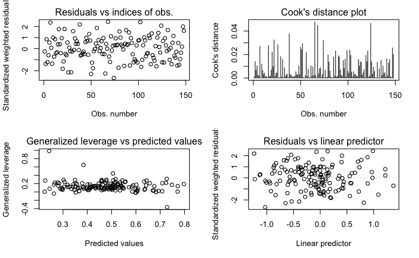

```r
par(mfrow = c(2, 2))
plot(model_ipi_fe_pred_lag)
```

Durbin-Watson test

```r
dwtest(model_ipi_fe_pred_lag)
```

```
    Durbin-Watson test

data:  model_ipi_fe_pred_lag
DW = 2.0745, p-value = 0.1847
alternative hypothesis: true autocorrelation is greater than 0
```

Autocorrelation plot

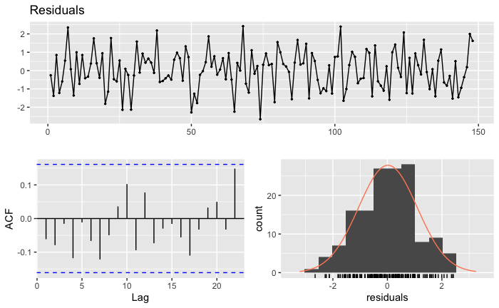

```r
checkresiduals(resid(model_ipi_fe_pred_lag))
```

### 0.11.2 Control of Corruption index

```r
model_coc_fe_pred_lag  = betareg(coc_norm~coc_norm_lag+country+assistance_man_per_capita+export_per_capita+visa_dialogue+v2smpolsoc+socialisation_coc+v2x_cspart |coc_norm_lag+country+assistance_man_per_capita+export_per_capita+visa_dialogue+v2smpolsoc+socialisation_coc+v2x_cspart, link = "logit", data = lag_df)
```

```r
show_output(model_coc_fe_pred_lag)
```

coc_norm

Predictors

Estimates

std. Error

(Intercept)

0.21 ***  
(0.13 – 0.33)

0.05

coc_norm_lag

17.62 ***  
(10.61 – 29.24)

4.56

country [Armenia]

1.09  
(0.90 – 1.30)

0.10

country [Azerbaijan]

0.35 *  
(0.14 – 0.85)

0.16

country [Bosnia and  
Herzegovina]

1.33 ***  
(1.17 – 1.52)

0.09

country [Croatia]

1.77 ***  
(1.40 – 2.24)

0.21

country [Georgia]

1.83 **  
(1.17 – 2.84)

0.41

country [Kosovo]

0.77 **  
(0.63 – 0.93)

0.07

country [Moldova]

0.88  
(0.71 – 1.09)

0.10

country [Montenegro]

1.64 ***  
(1.37 – 1.95)

0.15

country [North Macedonia]

1.73 ***  
(1.44 – 2.08)

0.16

country [Serbia]

1.40 ***  
(1.21 – 1.61)

0.10

country [Ukraine]

0.74  
(0.54 – 1.02)

0.12

assistance_man_per_capita

1.00 ***  
(1.00 – 1.00)

0.00

export_per_capita

1.00 ***  
(1.00 – 1.00)

0.00

visa_dialogue [1]

1.06  
(0.98 – 1.15)

0.04

visa_dialogue [2]

1.08  
(0.98 – 1.18)

0.05

v2smpolsoc

1.11 **  
(1.04 – 1.18)

0.04

socialisation_coc

1.27  
(0.68 – 2.35)

0.40

v2x_cspart

0.67  
(0.44 – 1.04)

0.15

Observations

148

R<sup>2</sup>

0.425

AIC

-491.395

log-Likelihood

285.698

- p<0.05 ** p<0.01 *** p<0.001

**DIAGNOSTICS**

Breush-Pagan test

```r
bptest(model_coc_fe_pred_lag)
```

```
    studentized Breusch-Pagan test

data:  model_coc_fe_pred_lag
BP = 22.09, df = 19, p-value = 0.2798
```

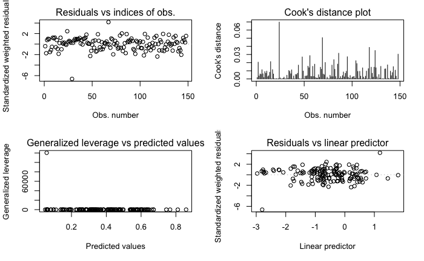

```r
par(mfrow = c(2, 2))
plot(model_coc_fe_pred_lag)
```

Durbin-Watson test

```r
dwtest(model_coc_fe_pred_lag)
```

```
    Durbin-Watson test

data:  model_coc_fe_pred_lag
DW = 2.1933, p-value = 0.4416
alternative hypothesis: true autocorrelation is greater than 0
```

Autocorrelation plot

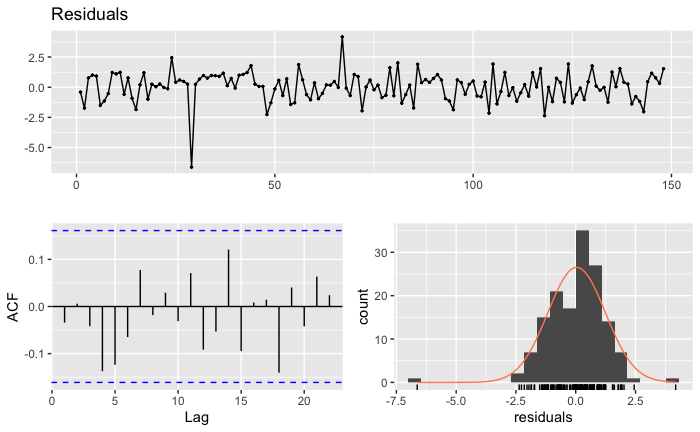

```r
checkresiduals(resid(model_coc_fe_pred_lag))
```

## 0.12 PLM + fixed effects

### 0.12.1 IPI-based index

```r
plm_model_ipi = plm(progress_ipi_logit~membership+visa_dialogue+ assistance_man_per_capita*e_wbgi_gee+v2x_cspart+v2smpolsoc+socialisation_ipi_logit+export_per_capita-e_wbgi_gee, df_base, index = c("country"), model = "within")
```

```r
show_output(plm_model_ipi)
```

[output not shown]

progress_ipi_logit

Predictors

Estimates

std. Error

visa_dialogue [1]

0.28 *  
(0.02 – 0.55)

0.14

visa_dialogue [2]

0.24  
(-0.12 – 0.60)

0.18

assistance_man_per_capita

0.00  
(-0.01 – 0.02)

0.01

v2x_cspart

3.29 ***  
(2.00 – 4.58)

0.66

v2smpolsoc

-0.11  
(-0.30 – 0.08)

0.10

socialisation_ipi_logit

0.07  
(-0.23 – 0.36)

0.15

export_per_capita

0.00  
(-0.00 – 0.00)

0.00

assistance_man_per_capita  
* e_wbgi_gee

0.03 **  
(0.01 – 0.05)

0.01

Observations

148

R<sup>2</sup> / R<sup>2</sup> adjusted

0.367 / 0.273

AIC

191.317

log-Likelihood

-86.658

- p<0.05 ** p<0.01 *** p<0.001

```r
#between r2 squared
print(r.squared(plm_model_ipi, model = "between"), dfcor = TRUE)
```

```
[1] 0.442411
```

```r
#within r2 squared
print(r.squared(plm_model_ipi, model = "within"), , dfcor = TRUE)
```

```
[1] 0.3672603
```

```r
#pooled r2 squared
print(r.squared(plm_model_ipi, model = "pooling"),, dfcor = TRUE)
```

```
[1] 0.2914162
```

**DIAGNOSTICS**

Breush-Pagan test

```r
bptest(plm_model_ipi)
```

```
    studentized Breusch-Pagan test

data:  plm_model_ipi
BP = 13.814, df = 9, p-value = 0.1291
```

Durbin-Watson test

```r
pdwtest(plm_model_ipi)
```

```
    Durbin-Watson test for serial correlation in panel models

data:  progress_ipi_logit ~ membership + visa_dialogue + assistance_man_per_capita *     e_wbgi_gee + v2x_cspart + v2smpolsoc + socialisation_ipi_logit +     export_per_capita - e_wbgi_gee
DW = 1.5381, p-value = 0.001157
alternative hypothesis: serial correlation in idiosyncratic errors
```

Autocorrelation plot

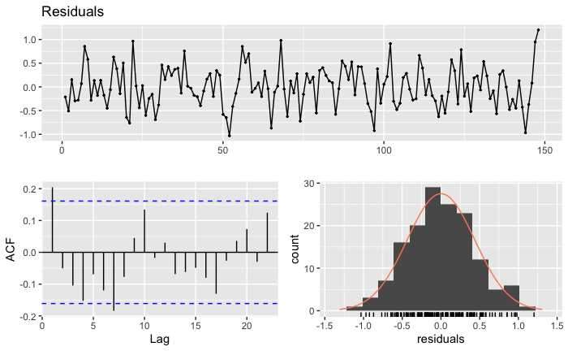

```r
checkresiduals(resid(plm_model_ipi))
```

### 0.12.2 Control of Corruption index

```r
plm_model_coc = plm(e_wbgi_cce~membership+visa_dialogue+ assistance_man_per_capita+v2x_cspart+v2smpolsoc+socialisation_e_wbgi_cce+export_per_capita, df_base, index = c("country"), model = "within")
```

```r
show_output(plm_model_coc)
```

[output not shown]

e_wbgi_cce

Predictors

Estimates

std. Error

visa_dialogue [1]

0.18 ***  
(0.12 – 0.25)

0.03

visa_dialogue [2]

0.19 ***  
(0.11 – 0.27)

0.04

assistance_man_per_capita

0.00  
(-0.00 – 0.00)

0.00

v2x_cspart

-0.17  
(-0.54 – 0.20)

0.19

v2smpolsoc

-0.10 ***  
(-0.15 – -0.04)

0.03

socialisation_e_wbgi_cce

-0.09  
(-0.33 – 0.14)

0.12

export_per_capita

-0.00 ***  
(-0.00 – -0.00)

0.00

Observations

148

R<sup>2</sup> / R<sup>2</sup> adjusted

0.326 / 0.232

AIC

-177.269

log-Likelihood

96.635

- p<0.05 ** p<0.01 *** p<0.001

```r
#between r2 squared - explanation between panels
print(r.squared(plm_model_coc, model = "between"), dfcor = TRUE)
```

```
[1] 0.05540073
```

```r
#within r2 squared - explanation within panel
print(r.squared(plm_model_coc, model = "within"), , dfcor = TRUE)
```

```
[1] 0.3261707
```

```r
#pooled r2 squared - weighted
print(r.squared(plm_model_coc, model = "pooling"),, dfcor = TRUE)
```

```
[1] 0.1327769
```

**DIAGNOSTICS**

Breush-Pagan test

```r
bptest(plm_model_coc)
```

```
    studentized Breusch-Pagan test

data:  plm_model_coc
BP = 42.389, df = 8, p-value = 1.145e-06
```

Durbin-Watson test

```r
pdwtest(plm_model_coc)
```

```
    Durbin-Watson test for serial correlation in panel models

data:  e_wbgi_cce ~ membership + visa_dialogue + assistance_man_per_capita +     v2x_cspart + v2smpolsoc + socialisation_e_wbgi_cce + export_per_capita
DW = 1.0862, p-value = 3.67e-09
alternative hypothesis: serial correlation in idiosyncratic errors
```

Autocorrelation plot

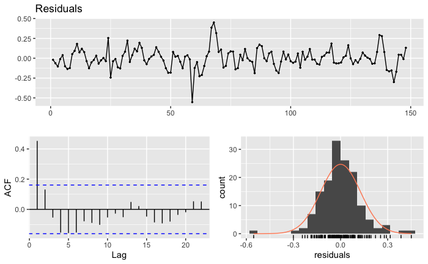

```r
checkresiduals(resid(plm_model_coc))
```

## 0.13 PLM + fixed effects + lagged variable

### 0.13.1 IPI-based index

```r
plm_model_ipi_lag = plm(progress_ipi_logit~progress_ipi_logit_lag+membership+visa_dialogue+ assistance_man_per_capita*e_wbgi_gee+v2x_cspart+v2smpolsoc+socialisation_ipi_logit+export_per_capita-e_wbgi_gee, lag_df, index = c("country"), model = "within")
```

```r
show_output(plm_model_ipi_lag)
```

progress_ipi_logit

Predictors

Estimates

std. Error

progress_ipi_logit_lag

0.39 ***  
(0.22 – 0.56)

0.09

visa_dialogue [1]

0.14  
(-0.12 – 0.39)

0.13

visa_dialogue [2]

0.02  
(-0.32 – 0.37)

0.18

assistance_man_per_capita

-0.00  
(-0.01 – 0.01)

0.01

v2x_cspart

2.10 **  
(0.79 – 3.41)

0.67

v2smpolsoc

-0.09  
(-0.27 – 0.09)

0.09

socialisation_ipi_logit

0.07  
(-0.20 – 0.35)

0.14

export_per_capita

0.00  
(-0.00 – 0.00)

0.00

assistance_man_per_capita  
* e_wbgi_gee

0.02 *  
(0.00 – 0.04)

0.01

Observations

148

R<sup>2</sup> / R<sup>2</sup> adjusted

0.455 / 0.369

AIC

171.194

log-Likelihood

-75.597

- p<0.05 ** p<0.01 *** p<0.001

```r
#between r2 squared - explanation between panels
print(r.squared(plm_model_ipi_lag, model = "between"), dfcor = TRUE)
```

```
[1] 0.6743172
```

```r
#within r2 squared - explanation within panel
print(r.squared(plm_model_ipi_lag, model = "within"), , dfcor = TRUE)
```

```
[1] 0.455112
```

```r
#pooled r2 squared - weighted
print(r.squared(plm_model_ipi_lag, model = "pooling"),, dfcor = TRUE)
```

```
[1] 0.4754819
```

**DIAGNOSTICS**

Breush-Pagan test

```r
bptest(plm_model_ipi_lag)
```

```
    studentized Breusch-Pagan test

data:  plm_model_ipi_lag
BP = 7.1935, df = 10, p-value = 0.7071
```

Durbin-Watson test

```r
pdwtest(plm_model_ipi_lag)
```

```
    Durbin-Watson test for serial correlation in panel models

data:  progress_ipi_logit ~ progress_ipi_logit_lag + membership + visa_dialogue +     assistance_man_per_capita * e_wbgi_gee + v2x_cspart + v2smpolsoc +     socialisation_ipi_logit + export_per_capita - e_wbgi_gee
DW = 2.0756, p-value = 0.5845
alternative hypothesis: serial correlation in idiosyncratic errors
```

Autocorrelation plot

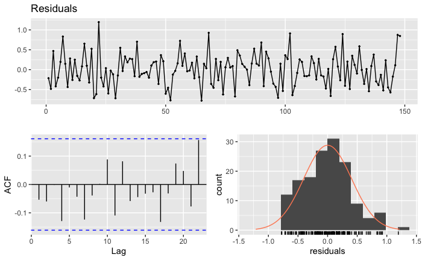

```r
checkresiduals(resid(plm_model_ipi_lag))
```

### 0.13.2 Control of Corruption index

```r
plm_model_coc_lag = plm(e_wbgi_cce~e_wbgi_cce_lag+membership+visa_dialogue+ assistance_man_per_capita+v2x_cspart+v2smpolsoc+socialisation_e_wbgi_cce+export_per_capita, lag_df, index = c("country"), model = "within")
```

```r
show_output(plm_model_coc_lag)
```

e_wbgi_cce

Predictors

Estimates

std. Error

e_wbgi_cce_lag

0.74 ***  
(0.63 – 0.85)

0.06

visa_dialogue [1]

0.05 *  
(0.01 – 0.10)

0.02

visa_dialogue [2]

0.04  
(-0.02 – 0.09)

0.03

assistance_man_per_capita

0.00  
(-0.00 – 0.00)

0.00

v2x_cspart

-0.10  
(-0.34 – 0.15)

0.12

v2smpolsoc

-0.04  
(-0.07 – 0.00)

0.02

socialisation_e_wbgi_cce

0.04  
(-0.11 – 0.19)

0.08

export_per_capita

-0.00 *  
(-0.00 – -0.00)

0.00

Observations

148

R<sup>2</sup> / R<sup>2</sup> adjusted

0.714 / 0.672

AIC

-302.171

log-Likelihood

160.085

- p<0.05 ** p<0.01 *** p<0.001

```r
#between r2 squared - explanation between panels
print(r.squared(plm_model_coc_lag, model = "between"), dfcor = TRUE)
```

```
[1] 0.9815181
```

```r
#within r2 squared - explanation within panel
print(r.squared(plm_model_coc_lag, model = "within"), , dfcor = TRUE)
```

```
[1] 0.7141302
```

```r
#pooled r2 squared - weighted
print(r.squared(plm_model_coc_lag, model = "pooling"),, dfcor = TRUE)
```

```
[1] 0.9264444
```

**DIAGNOSTICS**

Breush-Pagan test

```r
bptest(plm_model_coc_lag)
```

```
    studentized Breusch-Pagan test

data:  plm_model_coc_lag
BP = 14.246, df = 9, p-value = 0.1138
```

Durbin-Watson test

```r
pdwtest(plm_model_coc_lag)
```

```
    Durbin-Watson test for serial correlation in panel models

data:  e_wbgi_cce ~ e_wbgi_cce_lag + membership + visa_dialogue + assistance_man_per_capita +     v2x_cspart + v2smpolsoc + socialisation_e_wbgi_cce + export_per_capita
DW = 2.1938, p-value = 0.8259
alternative hypothesis: serial correlation in idiosyncratic errors
```

Autocorrelation plot

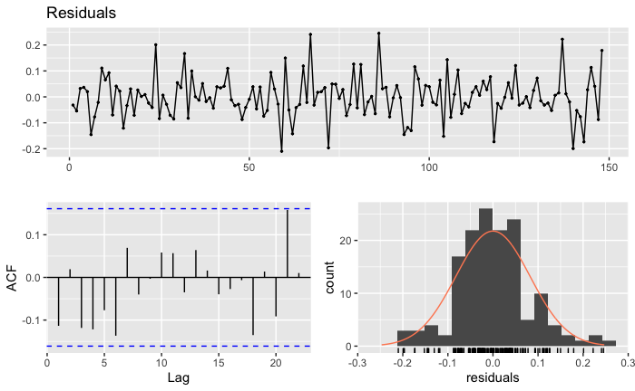

```r
checkresiduals(resid(plm_model_coc_lag))
```

## 0.14 Final results

2 models passed all tests: Beta regression with lagged variable and Panel regression with lagged variable

## 0.15 IPI-index

```r
knitr::knit_print(sjPlot::tab_model(model_ipi_fe_pred, model_ipi_fe_pred_lag, plm_model_ipi, plm_model_ipi_lag, show.se = TRUE, show.fstat = TRUE, show.aic = TRUE, show.loglik = TRUE, p.style = "stars", emph.p = TRUE, digits = 2, collapse.ci = TRUE))
```

progress_ipi

progress_ipi

progress_ipi_logit

progress_ipi_logit

Predictors

Estimates

std. Error

Estimates

std. Error

Estimates

std. Error

Estimates

std. Error

(Intercept)

0.08 ***  
(0.04 – 0.18)

0.03

0.08 ***  
(0.04 – 0.17)

0.03

country [Armenia]

1.46  
(0.94 – 2.26)

0.33

1.14  
(0.75 – 1.74)

0.25

country [Azerbaijan]

3.39 ***  
(1.98 – 5.82)

0.94

1.84 *  
(1.09 – 3.11)

0.49

country [Bosnia and  
Herzegovina]

0.57 **  
(0.38 – 0.85)

0.12

0.69  
(0.46 – 1.02)

0.14

country [Croatia]

1.03  
(0.56 – 1.89)

0.32

1.05  
(0.63 – 1.75)

0.27

country [Georgia]

1.81 **  
(1.19 – 2.76)

0.39

1.17  
(0.78 – 1.76)

0.24

country [Kosovo]

1.63 *  
(1.01 – 2.63)

0.40

1.53  
(0.99 – 2.37)

0.34

country [Moldova]

2.42 ***  
(1.78 – 3.31)

0.38

1.68 **  
(1.22 – 2.31)

0.28

country [Montenegro]

0.82  
(0.51 – 1.34)

0.20

0.75  
(0.45 – 1.24)

0.19

country [North Macedonia]

1.19  
(0.78 – 1.82)

0.26

0.94  
(0.65 – 1.37)

0.18

country [Serbia]

1.27  
(0.92 – 1.76)

0.21

1.08  
(0.78 – 1.51)

0.18

country [Ukraine]

1.16  
(0.80 – 1.70)

0.23

1.08  
(0.75 – 1.54)

0.20

assistance_man_per_capita

1.00  
(0.99 – 1.01)

0.00

1.00  
(0.99 – 1.01)

0.00

0.00  
(-0.01 – 0.02)

0.01

-0.00  
(-0.01 – 0.01)

0.01

export_per_capita

1.00  
(1.00 – 1.00)

0.00

1.00  
(1.00 – 1.00)

0.00

0.00  
(-0.00 – 0.00)

0.00

0.00  
(-0.00 – 0.00)

0.00

visa_dialogue [1]

1.77 ***  
(1.44 – 2.18)

0.19

1.27 *  
(1.02 – 1.58)

0.14

0.28 *  
(0.02 – 0.55)

0.14

0.14  
(-0.12 – 0.39)

0.13

visa_dialogue [2]

1.70 ***  
(1.26 – 2.28)

0.26

1.09  
(0.81 – 1.45)

0.16

0.24  
(-0.12 – 0.60)

0.18

0.02  
(-0.32 – 0.37)

0.18

v2smpolsoc

0.95  
(0.79 – 1.15)

0.09

0.90  
(0.77 – 1.06)

0.07

-0.11  
(-0.30 – 0.08)

0.10

-0.09  
(-0.27 – 0.09)

0.09

socialisation_ipi

1.11  
(0.40 – 3.06)

0.58

1.35  
(0.51 – 3.56)

0.67

v2x_cspart

12.87 ***  
(4.97 – 33.36)

6.26

6.41 ***  
(2.37 – 17.31)

3.25

3.29 ***  
(2.00 – 4.58)

0.66

2.10 **  
(0.79 – 3.41)

0.67

assistance_man_per_capita  
* e_wbgi_gee

1.01  
(1.00 – 1.02)

0.01

1.01  
(1.00 – 1.03)

0.01

0.03 **  
(0.01 – 0.05)

0.01

0.02 *  
(0.00 – 0.04)

0.01

progress_ipi_lag

6.40 ***  
(3.46 – 11.82)

2.00

socialisation_ipi_logit

0.07  
(-0.23 – 0.36)

0.15

0.07  
(-0.20 – 0.35)

0.14

progress_ipi_logit_lag

0.39 ***  
(0.22 – 0.56)

0.09

Observations

148

148

148

148

R<sup>2</sup>

0.533

0.624

0.367 / 0.273

0.455 / 0.369

AIC

-208.428

-225.835

191.317

171.194

log-Likelihood

144.214

154.917

-86.658

-75.597

- p<0.05 ** p<0.01 *** p<0.001

## 0.16 Control of corruption

coc_norm

coc_norm

e_wbgi_cce

e_wbgi_cce

Predictors

Estimates

std. Error

Estimates

std. Error

Estimates

std. Error

Estimates

std. Error

(Intercept)

0.59 *  
(0.36 – 0.97)

0.15

0.21 ***  
(0.13 – 0.33)

0.05

country [Armenia]

0.97  
(0.78 – 1.21)

0.11

1.09  
(0.90 – 1.30)

0.10

country [Azerbaijan]

0.30 **  
(0.13 – 0.71)

0.13

0.35 *  
(0.14 – 0.85)

0.16

country [Bosnia and  
Herzegovina]

1.75 ***  
(1.44 – 2.11)

0.17

1.33 ***  
(1.17 – 1.52)

0.09

country [Croatia]

5.28 ***  
(4.52 – 6.16)

0.42

1.77 ***  
(1.40 – 2.24)

0.21

country [Georgia]

6.81 ***  
(3.37 – 13.74)

2.44

1.83 **  
(1.17 – 2.84)

0.41

country [Kosovo]

1.02  
(0.81 – 1.29)

0.12

0.77 **  
(0.63 – 0.93)

0.07

country [Moldova]

0.77 *  
(0.61 – 0.96)

0.09

0.88  
(0.71 – 1.09)

0.10

country [Montenegro]

2.21 ***  
(1.83 – 2.68)

0.21

1.64 ***  
(1.37 – 1.95)

0.15

country [North Macedonia]

3.33 ***  
(2.74 – 4.04)

0.33

1.73 ***  
(1.44 – 2.08)

0.16

country [Serbia]

2.21 ***  
(1.90 – 2.59)

0.18

1.40 ***  
(1.21 – 1.61)

0.10

country [Ukraine]

0.49 ***  
(0.35 – 0.67)

0.08

0.74  
(0.54 – 1.02)

0.12

assistance_man_per_capita

1.00  
(1.00 – 1.01)

0.00

1.00 ***  
(1.00 – 1.00)

0.00

0.00  
(-0.00 – 0.00)

0.00

0.00  
(-0.00 – 0.00)

0.00

export_per_capita

1.00 ***  
(1.00 – 1.00)

0.00

1.00 ***  
(1.00 – 1.00)

0.00

-0.00 ***  
(-0.00 – -0.00)

0.00

-0.00 *  
(-0.00 – -0.00)

0.00

visa_dialogue [1]

1.28 ***  
(1.16 – 1.40)

0.06

1.06  
(0.98 – 1.15)

0.04

0.18 ***  
(0.12 – 0.25)

0.03

0.05 *  
(0.01 – 0.10)

0.02

visa_dialogue [2]

1.45 ***  
(1.32 – 1.59)

0.07

1.08  
(0.98 – 1.18)

0.05

0.19 ***  
(0.11 – 0.27)

0.04

0.04  
(-0.02 – 0.09)

0.03

v2smpolsoc

0.98  
(0.91 – 1.05)

0.03

1.11 **  
(1.04 – 1.18)

0.04

-0.10 ***  
(-0.15 – -0.04)

0.03

-0.04  
(-0.07 – 0.00)

0.02

socialisation_coc

0.54  
(0.26 – 1.11)

0.20

1.27  
(0.68 – 2.35)

0.40

v2x_cspart

0.76  
(0.43 – 1.33)

0.22

0.67  
(0.44 – 1.04)

0.15

-0.17  
(-0.54 – 0.20)

0.19

-0.10  
(-0.34 – 0.15)

0.12

coc_norm_lag

17.62 ***  
(10.61 – 29.24)

4.56

socialisation_e_wbgi_cce

-0.09  
(-0.33 – 0.14)

0.12

0.04  
(-0.11 – 0.19)

0.08

e_wbgi_cce_lag

0.74 ***  
(0.63 – 0.85)

0.06

Observations

148

148

148

148

R<sup>2</sup>

0.387

0.425

0.326 / 0.232

0.714 / 0.672

AIC

-433.453

-491.395

-177.269

-302.171

log-Likelihood

254.726

285.698

96.635

160.085

- p<0.05 ** p<0.01 *** p<0.001

## 0.17 Membership opportunity

```r
plm_model_coc_lag_membership = plm(e_wbgi_cce~e_wbgi_cce_lag+membership, lag_df, index = c("country"), model = "within")
```

### 0.17.2 Control of Corruption

```r
model_coc_fe_pred_lag_membership= betareg(coc_norm~coc_norm_lag+membership |coc_norm_lag+membership, link = "logit", data = lag_df)
```

```r
knitr::knit_print(sjPlot::tab_model(model_ipi_fe_pred_lag_membership, model_coc_fe_pred_lag_membership, show.se = TRUE, show.fstat = TRUE, show.aic = TRUE, show.loglik = TRUE, p.style = "stars", emph.p = TRUE, digits = 2, collapse.ci = TRUE))
```

progress_ipi

coc_norm

Predictors

Estimates

std. Error

Estimates

std. Error

(Intercept)

0.24 ***  
(0.19 – 0.32)

0.03

0.12 ***  
(0.10 – 0.15)

0.01

progress_ipi_lag

20.13 ***  
(12.11 – 33.46)

5.22

membership [1]

0.91  
(0.79 – 1.06)

0.07

1.00  
(0.81 – 1.22)

0.10

coc_norm_lag

63.86 ***  
(48.32 – 84.40)

9.09

Observations

148

148

R<sup>2</sup>

0.515

0.402

AIC

-238.609

-440.432

log-Likelihood

125.305

226.216

- p<0.05 ** p<0.01 *** p<0.001

## 0.18 Presentable results

In the end for this study I illustrate following model * fixed effects model * fixed effects model + lag * membership + lag

### 0.18.1 IPI-based index

```r
knitr::knit_print(sjPlot::tab_model(model_ipi_fe_pred, model_ipi_fe_pred_lag, model_ipi_fe_pred_lag_membership, show.se = TRUE, show.fstat = TRUE, show.aic = TRUE, show.loglik = TRUE, p.style = "stars", emph.p = TRUE, digits = 2, collapse.ci = TRUE))
```

progress_ipi

progress_ipi

progress_ipi

Predictors

Estimates

std. Error

Estimates

std. Error

Estimates

std. Error

(Intercept)

0.08 ***  
(0.04 – 0.18)

0.03

0.08 ***  
(0.04 – 0.17)

0.03

0.24 ***  
(0.19 – 0.32)

0.03

country [Armenia]

1.46  
(0.94 – 2.26)

0.33

1.14  
(0.75 – 1.74)

0.25

country [Azerbaijan]

3.39 ***  
(1.98 – 5.82)

0.94

1.84 *  
(1.09 – 3.11)

0.49

country [Bosnia and  
Herzegovina]

0.57 **  
(0.38 – 0.85)

0.12

0.69  
(0.46 – 1.02)

0.14

country [Croatia]

1.03  
(0.56 – 1.89)

0.32

1.05  
(0.63 – 1.75)

0.27

country [Georgia]

1.81 **  
(1.19 – 2.76)

0.39

1.17  
(0.78 – 1.76)

0.24

country [Kosovo]

1.63 *  
(1.01 – 2.63)

0.40

1.53  
(0.99 – 2.37)

0.34

country [Moldova]

2.42 ***  
(1.78 – 3.31)

0.38

1.68 **  
(1.22 – 2.31)

0.28

country [Montenegro]

0.82  
(0.51 – 1.34)

0.20

0.75  
(0.45 – 1.24)

0.19

country [North Macedonia]

1.19  
(0.78 – 1.82)

0.26

0.94  
(0.65 – 1.37)

0.18

country [Serbia]

1.27  
(0.92 – 1.76)

0.21

1.08  
(0.78 – 1.51)

0.18

country [Ukraine]

1.16  
(0.80 – 1.70)

0.23

1.08  
(0.75 – 1.54)

0.20

assistance_man_per_capita

1.00  
(0.99 – 1.01)

0.00

1.00  
(0.99 – 1.01)

0.00

export_per_capita

1.00  
(1.00 – 1.00)

0.00

1.00  
(1.00 – 1.00)

0.00

visa_dialogue [1]

1.77 ***  
(1.44 – 2.18)

0.19

1.27 *  
(1.02 – 1.58)

0.14

visa_dialogue [2]

1.70 ***  
(1.26 – 2.28)

0.26

1.09  
(0.81 – 1.45)

0.16

v2smpolsoc

0.95  
(0.79 – 1.15)

0.09

0.90  
(0.77 – 1.06)

0.07

socialisation_ipi

1.11  
(0.40 – 3.06)

0.58

1.35  
(0.51 – 3.56)

0.67

v2x_cspart

12.87 ***  
(4.97 – 33.36)

6.26

6.41 ***  
(2.37 – 17.31)

3.25

assistance_man_per_capita  
* e_wbgi_gee

1.01  
(1.00 – 1.02)

0.01

1.01  
(1.00 – 1.03)

0.01

progress_ipi_lag

6.40 ***  
(3.46 – 11.82)

2.00

20.13 ***  
(12.11 – 33.46)

5.22

membership [1]

0.91  
(0.79 – 1.06)

0.07

Observations

148

148

148

R<sup>2</sup>

0.533

0.624

0.515

AIC

-208.428

-225.835

-238.609

log-Likelihood

144.214

154.917

125.305

- p<0.05 ** p<0.01 *** p<0.001

### 0.18.2 Control of Corruption

```r
knitr::knit_print(sjPlot::tab_model(model_coc_fe_pred, model_coc_fe_pred_lag,model_coc_fe_pred_lag_membership, show.se = TRUE, show.fstat = TRUE, show.aic = TRUE, show.loglik = TRUE, p.style = "stars", emph.p = TRUE, digits = 2, collapse.ci = TRUE))
```

coc_norm

coc_norm

coc_norm

Predictors

Estimates

std. Error

Estimates

std. Error

Estimates

std. Error

(Intercept)

0.59 *  
(0.36 – 0.97)

0.15

0.21 ***  
(0.13 – 0.33)

0.05

0.12 ***  
(0.10 – 0.15)

0.01

country [Armenia]

0.97  
(0.78 – 1.21)

0.11

1.09  
(0.90 – 1.30)

0.10

country [Azerbaijan]

0.30 **  
(0.13 – 0.71)

0.13

0.35 *  
(0.14 – 0.85)

0.16

country [Bosnia and  
Herzegovina]

1.75 ***  
(1.44 – 2.11)

0.17

1.33 ***  
(1.17 – 1.52)

0.09

country [Croatia]

5.28 ***  
(4.52 – 6.16)

0.42

1.77 ***  
(1.40 – 2.24)

0.21

country [Georgia]

6.81 ***  
(3.37 – 13.74)

2.44

1.83 **  
(1.17 – 2.84)

0.41

country [Kosovo]

1.02  
(0.81 – 1.29)

0.12

0.77 **  
(0.63 – 0.93)

0.07

country [Moldova]

0.77 *  
(0.61 – 0.96)

0.09

0.88  
(0.71 – 1.09)

0.10

country [Montenegro]

2.21 ***  
(1.83 – 2.68)

0.21

1.64 ***  
(1.37 – 1.95)

0.15

country [North Macedonia]

3.33 ***  
(2.74 – 4.04)

0.33

1.73 ***  
(1.44 – 2.08)

0.16

country [Serbia]

2.21 ***  
(1.90 – 2.59)

0.18

1.40 ***  
(1.21 – 1.61)

0.10

country [Ukraine]

0.49 ***  
(0.35 – 0.67)

0.08

0.74  
(0.54 – 1.02)

0.12

assistance_man_per_capita

1.00  
(1.00 – 1.01)

0.00

1.00 ***  
(1.00 – 1.00)

0.00

export_per_capita

1.00 ***  
(1.00 – 1.00)

0.00

1.00 ***  
(1.00 – 1.00)

0.00

visa_dialogue [1]

1.28 ***  
(1.16 – 1.40)

0.06

1.06  
(0.98 – 1.15)

0.04

visa_dialogue [2]

1.45 ***  
(1.32 – 1.59)

0.07

1.08  
(0.98 – 1.18)

0.05

v2smpolsoc

0.98  
(0.91 – 1.05)

0.03

1.11 **  
(1.04 – 1.18)

0.04

socialisation_coc

0.54  
(0.26 – 1.11)

0.20

1.27  
(0.68 – 2.35)

0.40

v2x_cspart

0.76  
(0.43 – 1.33)

0.22

0.67  
(0.44 – 1.04)

0.15

coc_norm_lag

17.62 ***  
(10.61 – 29.24)

4.56

63.86 ***  
(48.32 – 84.40)

9.09

membership [1]

1.00  
(0.81 – 1.22)

0.10

Observations

148

148

148

R<sup>2</sup>

0.387

0.425

0.402

AIC

-433.453

-491.395

-440.432

log-Likelihood

254.726

285.698

226.216

- p<0.05 ** p<0.01 *** p<0.001

## 0.19 Notes

No problems with membership models

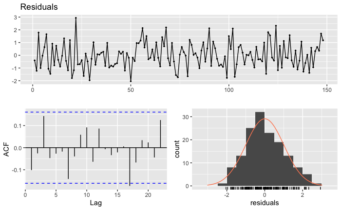

```r
checkresiduals(resid(model_ipi_fe_pred_lag_membership))
```

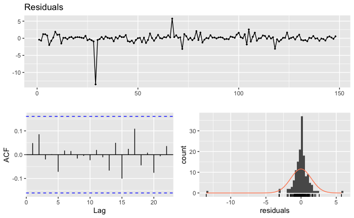

```r
checkresiduals(resid(model_coc_fe_pred_lag_membership))
```

## 0.20 Predictions

Let’s get predicted values first

```r
lag_df$pred_ipi =  predict(model_ipi_fe_pred_lag, lag_df)
lag_df$pred_coc =  predict(model_coc_fe_pred_lag, lag_df)
```

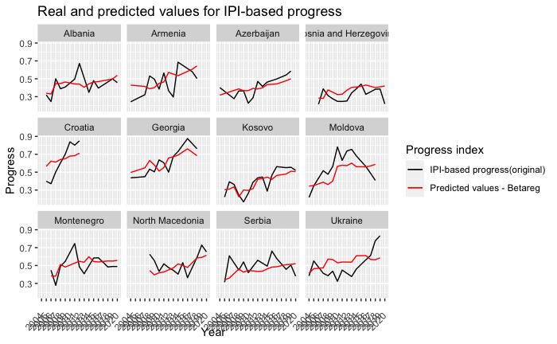

```r
ggplot(df_base) +
  geom_line(aes(year, progress_ipi, col = "black")) +
  geom_line(aes(year, pred_ipi, col = "red"))+
  facet_wrap(~country) +
  scale_x_continuous(breaks = seq(2003,2020, 1))+
  theme(axis.text.x = element_text(angle = 45, vjust = 0.5, hjust=1))+
  scale_color_identity(name = "Progress index",
                          breaks = c("black", "red"),
                          labels = c("IPI-based progress(original)", "Predicted values - Betareg"),
                          guide = "legend")+
  ylab("Progress")+
  xlab("Year")+
  ggtitle("Real and predicted values for IPI-based progress")
```

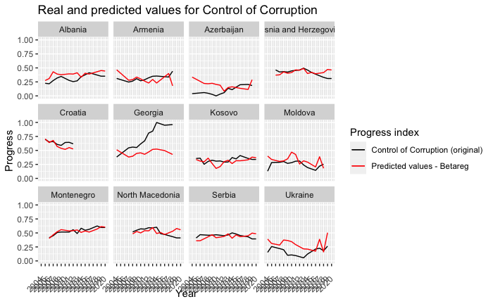

```r
ggplot(df_base) +
  geom_line(aes(year, coc_norm, col = "black")) +
  geom_line(aes(year, pred_coc, col = "red"))+
  facet_wrap(~country) +
  scale_x_continuous(breaks = seq(2003,2020, 1))+
  theme(axis.text.x = element_text(angle = 45, vjust = 0.5, hjust=1))+
  scale_color_identity(name = "Progress index",
                          breaks = c("black", "red"),
                          labels = c("Control of Corruption (original)", "Predicted values - Betareg"),
                          guide = "legend")+
  ylab("Progress")+
  xlab("Year")+
  ggtitle("Real and predicted values for Control of Corruption")
```